# Sexual selection and extinction: a macro-evolutionary approach

Supplementary Material

Justin G. Cally<sup>1</sup>, Iliana Medina Guzmán<sup>1</sup> Luke Holman<sup>1</sup>, Devi Stuart-Fox<sup>1</sup> <sup>1</sup>The University of Melbourne

Here we provide the supplementary material for our study on sexual selection and extinction risk in passerine birds.

# Compiling the data

For this project we aimed to compile data on a large set of species in the Passerine bird order that would allow us to account for many evolutionary and environmental predictors of extinction. The following details the source and use of the data.

## Extinction Risk

To obtain extinction risk estimates we used Bayesian Analysis of Macroevolutionary Mixtures (BAMM). We document the control file and process for obtaining extinction rates from BAMM in an accompanying R markdown in the `BAMM` folder. Additionally, we compared our BAMM output files (event data) against a pre-existing extinction rate dataset [1].

[2] also provides us with a compiled IUCN threat level listing for all species from 2010 standings.

## Sexual Selection

Our proxy for sexual selection was based on measures of sexual dichromatism. Notably, we use two existing datasets; a complete set of male and female plumage scores in Passerines from [3] and reflectance data from 1000 birds from [4].

Briefly, [3] obtained male and female plumage score, which can be divided to obtain a sexual dimorphism index (SDi). The plumage score was scored using the *Handbook of the Birds of the World* [5]. By scanning images of males and females in this book across multiple patches [3] were able to obtain mean plumage scores from RGB values. Notably concern about the accuracy of these measurements were raised, thus this dataset was previously compared with a more thorough reflectance dataset of Australian birds, the two datasets correlated but was expectedly noisy (R2 = 0.67, P < 0.0001). Here we compare the [3] data against another reflectance dataset from [4] which has colour discriminability, segment classification and PCA.

Alongside sexual dichromatism data there is also partial data for other metrics analysed in [3] such as: Body size, tropical life history, Sexual selection, Cooperative breeding and Migration.

## Environmental predictors

We obtained species range distribution maps from Birdlife International (through IUCN). These species range maps cover ~ 7,000 species of birds. From these ranges we were able to obtain estimates of:

- Range Size
- Average and standard deviation in 19 bioclimatic variables (each range randomly sampled 1000 times)
- Average and standard deviation in 19 bioclimatic variables from the last glaciam maximum (LGM)
- Net primary productivity (NPP) estimates and variability
- Average and standard deviation of population density in the species ranges.

# Generating biologically relevent predictors of extinction

Here we assess the relationship between sexual selection and extinction risk. However, in doing so we attempt to take into account as many other predictors of extinction as possible, primarily through environmental variables. Basically, our model structure seeks to contain:

Extinction rate ~ Sexual selection + Range size + Short temporal variability of temperature (mean BIOCLIM4) + Short temporal variability of precipitation (mean BIOCLIM15) + Spatial variability of temperature (PCA1) + Spatial variability of precipitation (PCA2) + Long-term variability of temperature (BIOCLIM1) + Long-term variability of precipitation (BIOCLIM12) + Variability of NPP

These predictors can be generated from the compiled datasets seen here:

```r
complete.dataframe <- read.csv('data/complete.dataframe.csv')
```

## Spatial Variability PCAs

To obtain estimates of spatial variability we can obtain PCAs of the standard errors of the bioclimatic variables (excluding seasonality in temperature and precipitation). From there we can run GAM models with the PCA components and range size and extract residuals. We do this as we expect variability will increase alongside increased range size, thus taking the residuals allows us to correct for this association.

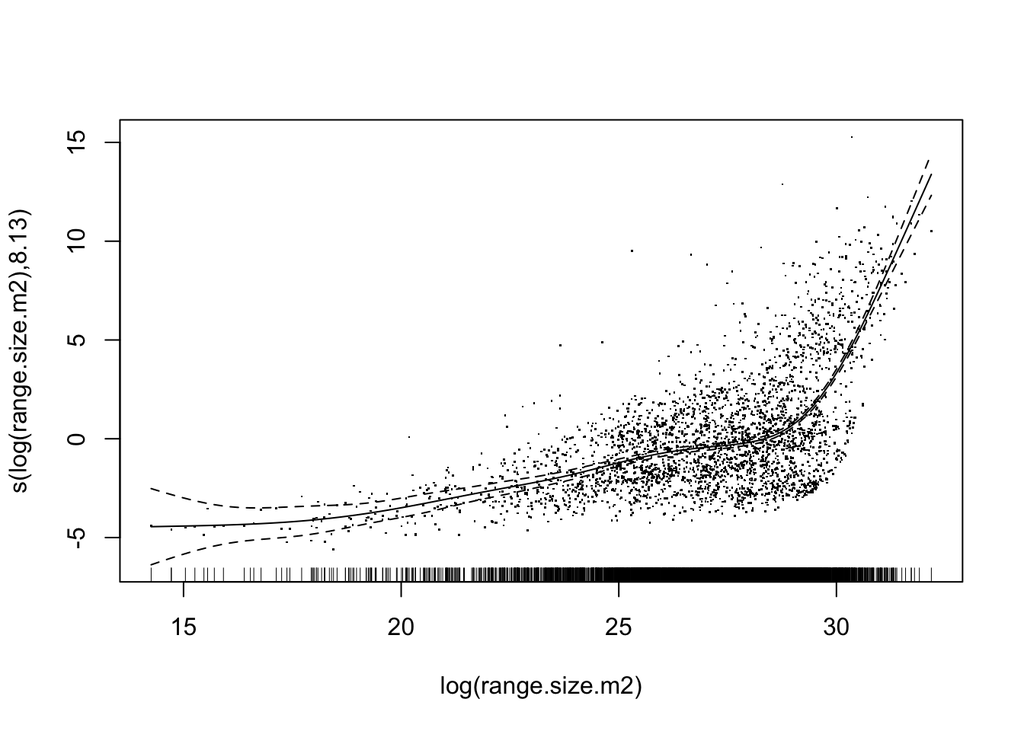

```r
restricted.data <- complete.dataframe %>% drop_na(bioclim1) #Drop species without environmental data
PCA.bioclim <- prcomp(restricted.data[c(34,35,36,38:47,49:52)], #Select se.bioclim
                      scale = TRUE, center = TRUE)
PCA.predictions <- predict(PCA.bioclim)
restricted.data <- cbind(restricted.data, PCA.predictions)

#run GAM
PC1.gam <- mgcv::gam(PC1 ~ s(log(range.size.m2)), data = restricted.data, family = "gaussian")

#take residuals
restricted.data$residuals.PC1 <- residuals.gam(PC1.gam)

#plot
plot.gam(PC1.gam, residuals = T)
```

We can do the same for PC2 (precipitation)

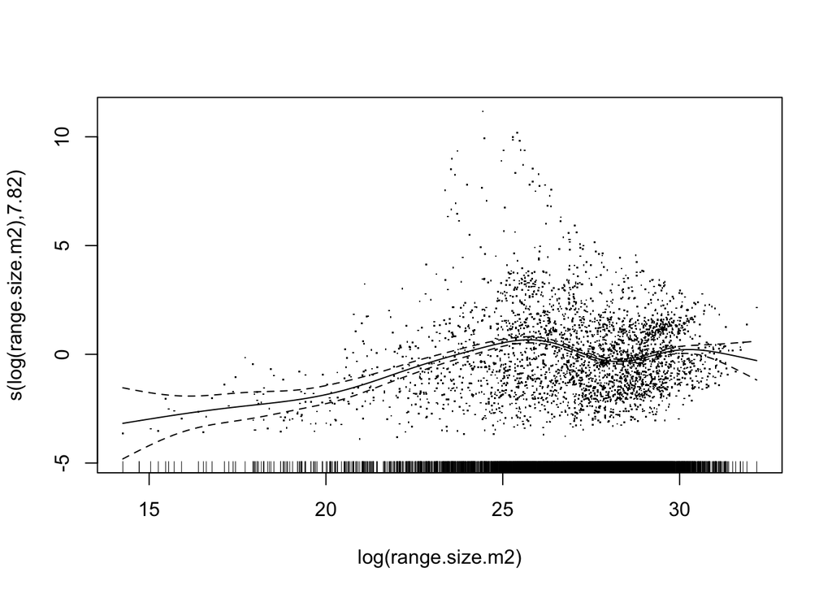

```r
PC2.gam <- mgcv::gam(PC2 ~ s(log(range.size.m2)), data = restricted.data, family = "gaussian")

#Take residuals
restricted.data$residuals.PC2 <- residuals.gam(PC2.gam)

plot.gam(PC2.gam, residuals = T)
```

## Long term climate variability (LGM anomaly)

To gain estimates for change in climate over the past 22,000 we can use the difference in annual mean temperature (BIO1) and annual precipitation (BIO12) between the LGM (CCSM4 models) and present values. Additionally we can calculate the difference in variability based on the standard deviation, although these will be correlated and thus maybe using only one of them (either mean or variability difference) in the analysis may be better.

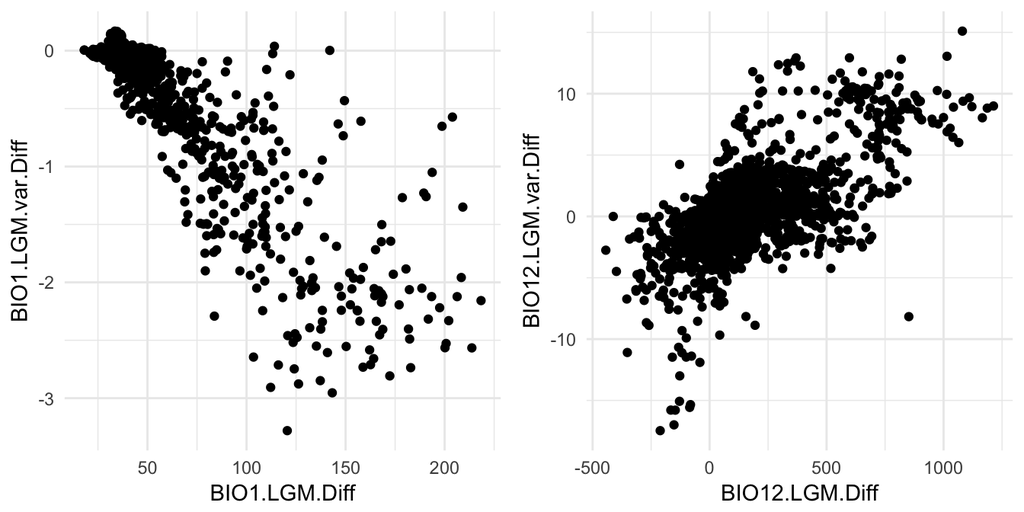

```r
#Change in mean temp
restricted.data$BIO1.LGM.Diff <- restricted.data$bioclim1 - restricted.data$cclgmbi1
#Change in variation temp
restricted.data$BIO1.LGM.var.Diff <- restricted.data$se.bioclim1 - restricted.data$se.cclgmbi1

#Change in mean precipitation
restricted.data$BIO12.LGM.Diff <- restricted.data$bioclim12 - restricted.data$cclgmbi12
#Change in variation precipitation
restricted.data$BIO12.LGM.var.Diff <- restricted.data$se.bioclim12 - restricted.data$se.cclgmbi12

#Inspect these changes
bio1.plot <- restricted.data %>% ggplot(aes(x=BIO1.LGM.Diff, y = BIO1.LGM.var.Diff))+
  geom_point()+
  theme_minimal()

bio12.plot <- restricted.data %>% ggplot(aes(x=BIO12.LGM.Diff, y = BIO12.LGM.var.Diff))+
  geom_point()+
  theme_minimal()

grid.arrange(bio1.plot, bio12.plot, ncol=2)
```

From these plots we can see that on average temperature has increased but the variation in tempere has decresed (narrowed). Alternatively, precipitation sometimes increases and sometimes decreases. When precipitation increases there isw also an increase in variation in that range. However, when annual precipitation decreases there is a decrease in variation.

## Variation in NPP

Similar to the PCA’s we expect NPP variation to be correlated with range size. To account for this we can run a GAM and obtain residuals.

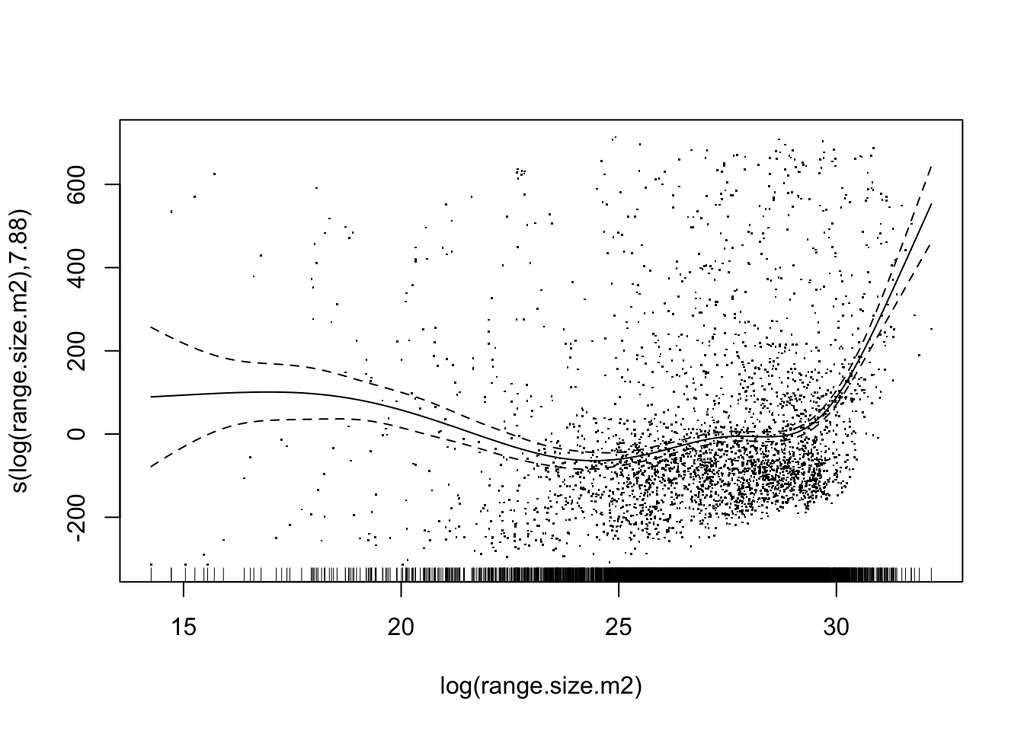

```r
#run gam
NPP.gam <- mgcv::gam(NPP.se ~ s(log(range.size.m2)), data = restricted.data, family = "gaussian")

#obtain residuals
restricted.data$NPP.res <- residuals.gam(NPP.gam)

#plot
plot(NPP.gam, residuals = T)
```

## Preliminary analysis of data

### Examining BAMM rates

Now that we have all our relevent predictors we can combine these with the tip extinction rates from BAMM (code for this is provided in the repository). First, let us inspect the tip rates that [1] obtained in BAMM with our predictors.

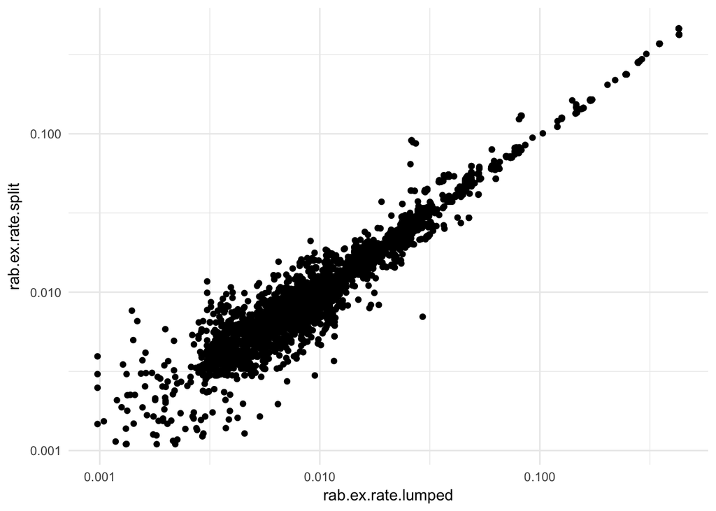

```r
complete.dataframe %>% ggplot(aes(x=rab.ex.rate.lumped, y=rab.ex.rate.split))+
  geom_point()+
  scale_x_log10()+
  scale_y_log10()+
  theme_minimal()
```

### Fixed-effect models

The extinction rates of the lumped and split datasets show high similarity and we could arguably use either. Let’s ude ‘split’:

First with a simple linear model that is not phylogenetically corrected:

```r
model.1 <- lm(rab.ex.rate.split ~ SDi
                + range.size.m2
                + bioclim4
                + bioclim15
                + residuals.PC1
                + residuals.PC2
                + BIO1.LGM.Diff
                + BIO12.LGM.Diff
                + NPP.res,
                data = restricted.data)
summary(model.1)
```

```
##
## Call:
## lm(formula = rab.ex.rate.split ~ SDi + range.size.m2 + bioclim4 +
##     bioclim15 + residuals.PC1 + residuals.PC2 + BIO1.LGM.Diff +
##     BIO12.LGM.Diff + NPP.res, data = restricted.data)
##
## Residuals:
##      Min       1Q   Median       3Q      Max
## -0.07184 -0.01760 -0.00824  0.00407  0.43426
##
## Coefficients:
##                  Estimate Std. Error t value Pr(>|t|)
## (Intercept)    -2.403e-02  6.043e-03  -3.976 7.16e-05 ***
## SDi             4.962e-02  4.671e-03  10.623  < 2e-16 ***
## range.size.m2   2.800e-16  1.868e-16   1.499   0.1341
## bioclim4       -3.245e-06  5.279e-07  -6.148 8.87e-10 ***
## bioclim15       2.711e-05  4.129e-05   0.656   0.5116
## residuals.PC1   7.954e-04  5.448e-04   1.460   0.1444
## residuals.PC2  -1.102e-03  5.493e-04  -2.006   0.0449 *
## BIO1.LGM.Diff   5.853e-05  4.921e-05   1.189   0.2344
## BIO12.LGM.Diff -1.054e-05  4.422e-06  -2.385   0.0172 *
## NPP.res         3.626e-05  5.089e-06   7.126 1.28e-12 ***
## ---
## Signif. codes:  0 '***' 0.001 '**' 0.01 '*' 0.05 '.' 0.1 ' ' 1
##
## Residual standard error: 0.04576 on 3080 degrees of freedom
##   (40 observations deleted due to missingness)
## Multiple R-squared:  0.06773,    Adjusted R-squared:  0.06501
## F-statistic: 24.86 on 9 and 3080 DF,  p-value: < 2.2e-16
```

Secondly, we can use a PGLS model:

```r
hackett.consensus.tree <- read.nexus('bamm_extinction/data/trees/hackett_dale_sub.consensus.nex')
restricted.data <- restricted.data %>% drop_na(rab.ex.rate.split)
rownames(restricted.data) <- restricted.data$TipLabel
pruned.tree<-drop.tip(hackett.consensus.tree,hackett.consensus.tree$tip.label[-match(restricted.data$TipLabel, hackett.consensus.tree$tip.label)])
pgls.model.1 <- gls(rab.ex.rate.split ~ SDi
                + range.size.m2
                + bioclim4
                + bioclim15
                + residuals.PC1
                + residuals.PC2
                + BIO1.LGM.Diff
                + BIO12.LGM.Diff
                + NPP.res,
                correlation = corBrownian(phy = pruned.tree),
                data = restricted.data,
                method = "REML")
summary(pgls.model.1)
```

```
## Generalized least squares fit by REML
##   Model: rab.ex.rate.split ~ SDi + range.size.m2 + bioclim4 + bioclim15 +      residuals.PC1 + residuals.PC2 + BIO1.LGM.Diff + BIO12.LGM.Diff +      NPP.res
##   Data: restricted.data
##        AIC       BIC   logLik
##   -16967.9 -16901.54 8494.951
##
## Correlation Structure: corBrownian
##  Formula: ~1
##  Parameter estimate(s):
## numeric(0)
##
## Coefficients:
##                       Value   Std.Error    t-value p-value
## (Intercept)     0.008004750 0.015587247  0.5135448  0.6076
## SDi             0.000427031 0.001216587  0.3510071  0.7256
## range.size.m2   0.000000000 0.000000000  0.1529915  0.8784
## bioclim4       -0.000000075 0.000000141 -0.5321432  0.5947
## bioclim15       0.000001546 0.000009936  0.1556317  0.8763
## residuals.PC1   0.000011718 0.000142929  0.0819834  0.9347
## residuals.PC2  -0.000039779 0.000128393 -0.3098242  0.7567
## BIO1.LGM.Diff   0.000004029 0.000012072  0.3337344  0.7386
## BIO12.LGM.Diff -0.000000242 0.000001114 -0.2167557  0.8284
## NPP.res         0.000001782 0.000001266  1.4072323  0.1595
##
##  Correlation:
##                (Intr) SDi    rng..2 biclm4 bclm15 rs.PC1 rs.PC2 BIO1.L
## SDi            -0.083
## range.size.m2   0.010  0.121
## bioclim4       -0.007 -0.082 -0.414
## bioclim15      -0.042  0.062 -0.163  0.008
## residuals.PC1   0.018  0.047  0.415 -0.437 -0.214
## residuals.PC2  -0.023  0.108 -0.265  0.202  0.251 -0.245
## BIO1.LGM.Diff  -0.025 -0.006 -0.215 -0.410  0.242 -0.048  0.035
## BIO12.LGM.Diff -0.007 -0.018  0.068  0.018  0.012  0.042 -0.271  0.002
## NPP.res         0.008 -0.043  0.153 -0.041 -0.175 -0.176  0.032  0.044
##                BIO12.
## SDi
## range.size.m2
## bioclim4
## bioclim15
## residuals.PC1
## residuals.PC2
## BIO1.LGM.Diff
## BIO12.LGM.Diff
## NPP.res         0.068
##
## Standardized residuals:
##         Min          Q1         Med          Q3         Max
## -0.18170315 -0.04543224  0.07961979  0.36604896 10.59641806
##
## Residual standard error: 0.04272914
## Degrees of freedom: 3090 total; 3080 residual
```

It is likely that given the underestimation of rate shifts by BAMM we obtain groups of similar speciation/extinction rates and thus when used in PGLS the highly correlated species will have near exact extinction/speciation rates. Giving less weight to these results.

Additionally, we can run a PGLS with an OU model rather than Brownian:

```r
pgls.model.3 <- gls(rab.ex.rate.split ~ SDi
                + range.size.m2
                + bioclim4
                + bioclim15
                + residuals.PC1
                + residuals.PC2
                + BIO1.LGM.Diff
                + BIO12.LGM.Diff
                + NPP.res,
                correlation = corMartins(1, phy = pruned.tree),
                data = restricted.data,
                method = "REML")
summary(pgls.model.3)
```

```
## Generalized least squares fit by REML
##   Model: rab.ex.rate.split ~ SDi + range.size.m2 + bioclim4 + bioclim15 +      residuals.PC1 + residuals.PC2 + BIO1.LGM.Diff + BIO12.LGM.Diff +      NPP.res
##   Data: restricted.data
##         AIC       BIC   logLik
##   -17021.96 -16949.57 8522.979
##
## Correlation Structure: corMartins
##  Formula: ~1
##  Parameter estimate(s):
##      alpha
## 0.02131976
##
## Coefficients:
##                       Value   Std.Error    t-value p-value
## (Intercept)     0.008770415 0.008458464  1.0368804  0.2999
## SDi             0.000749091 0.001302931  0.5749276  0.5654
## range.size.m2   0.000000000 0.000000000  0.2366483  0.8129
## bioclim4       -0.000000101 0.000000150 -0.6740527  0.5003
## bioclim15       0.000002048 0.000010586  0.1934240  0.8466
## residuals.PC1   0.000013176 0.000151406  0.0870238  0.9307
## residuals.PC2  -0.000040908 0.000136656 -0.2993515  0.7647
## BIO1.LGM.Diff   0.000004347 0.000012878  0.3375515  0.7357
## BIO12.LGM.Diff -0.000000271 0.000001183 -0.2289990  0.8189
## NPP.res         0.000002103 0.000001346  1.5627701  0.1182
##
##  Correlation:
##                (Intr) SDi    rng..2 biclm4 bclm15 rs.PC1 rs.PC2 BIO1.L
## SDi            -0.165
## range.size.m2   0.019  0.114
## bioclim4       -0.010 -0.079 -0.415
## bioclim15      -0.088  0.057 -0.162  0.006
## residuals.PC1   0.035  0.043  0.415 -0.438 -0.214
## residuals.PC2  -0.042  0.100 -0.265  0.210  0.252 -0.250
## BIO1.LGM.Diff  -0.053 -0.005 -0.214 -0.418  0.246 -0.049  0.033
## BIO12.LGM.Diff -0.017 -0.016  0.067  0.022  0.018  0.041 -0.272  0.000
## NPP.res         0.019 -0.039  0.150 -0.048 -0.172 -0.179  0.040  0.043
##                BIO12.
## SDi
## range.size.m2
## bioclim4
## bioclim15
## residuals.PC1
## residuals.PC2
## BIO1.LGM.Diff
## BIO12.LGM.Diff
## NPP.res         0.066
##
## Standardized residuals:
##         Min          Q1         Med          Q3         Max
## -0.32687022 -0.11108855  0.08478327  0.53341297 16.52553347
##
## Residual standard error: 0.02732886
## Degrees of freedom: 3090 total; 3080 residual
```

### Bayesian models

```r
pruned.tree$edge.length[pruned.tree$edge.length<0]<-1e-9
pruned.tree$edge.length[pruned.tree$edge.length==0]<-1e-9
pruned.tree <- check_and_fix_ultrametric(pruned.tree)
inv.phylo <- MCMCglmm::inverseA(pruned.tree, nodes = "TIPS", scale = TRUE)
A <- solve(inv.phylo$Ainv)
rownames(A) <- rownames(inv.phylo$Ainv)
```

```r
# model_bayesian <- brm(
#   rab.ex.rate.split ~ SDi
#                 + range.size.m2
#                 + bioclim4
#                 + bioclim15
#                 + residuals.PC1
#                 + residuals.PC2
#                 + BIO1.LGM.Diff
#                 + BIO12.LGM.Diff
#                 + NPP.res, data = restricted.data,
#   family = gaussian(),
#   cov_ranef = list(phylo = A),
#                 seed = 1,
#                 cores = 4, chains = 4, iter = 4000, #Run 4 chains in parallel for 4000 iterations (2000 are burn in)
#                 control = list(adapt_delta = 0.99, max_treedepth = 15))
```

```r
#summary(model_bayesian)
```

### Diversification rate (DR) estimates as opposed to BAMM

Diversification rates can be simply estimated from thew ‘tippiness of the phylogeny’. Here an equal splits (ES) value can be achieved that is weighted to more recent diversification. It was used by [2] and recently (in comparison with BAMM) in a study ivestigation bird diversity alongside elevation [6].WE CAN look at speciation rate using ES-Sim adapted by [7] and found here https://github.com/mgharvey/ES-sim.

```r
Essim.frame <- restricted.data$SDi
names(Essim.frame) <- restricted.data$TipLabel

essim.results <- essim(pruned.tree, Essim.frame, nsim = 1000, return.es = TRUE)
#Independent correlation results for ES-sim
essim.stats <- cbind(essim.results[["rho"]], essim.results[["P Value"]])
colnames(essim.stats) <- c("rho", "P value")
essim.stats %>% pander(digits = 2)
```

| rho | P value |
| --- | --- |
| 0.044 | 0.6 |

These results suggest there is not a correlation between the diversification rate (log(ES)) and sexual dichromatism. However. We should look at this in a larger model and with phylogenetic correction. To do that we can obtain the ES values (tip rates) for each species, the log of these is the diversification rate used by [2] and [6].

```r
restricted.data$ESsim <- essim.results[["es"]]

#OU model using ES-sim

pgls.model.4 <- gls(ESsim ~ SDi
                + range.size.m2
                + bioclim4
                + bioclim15
                + residuals.PC1
                + residuals.PC2
                + BIO1.LGM.Diff
                + BIO12.LGM.Diff
                + NPP.res,
                correlation = corMartins(1, phy = pruned.tree),
                data = restricted.data,
                method = "REML")
summary(pgls.model.4)
```

```
## Generalized least squares fit by REML
##   Model: ESsim ~ SDi + range.size.m2 + bioclim4 + bioclim15 + residuals.PC1 +      residuals.PC2 + BIO1.LGM.Diff + BIO12.LGM.Diff + NPP.res
##   Data: restricted.data
##        AIC      BIC    logLik
##   4409.895 4482.287 -2192.947
##
## Correlation Structure: corMartins
##  Formula: ~1
##  Parameter estimate(s):
##   alpha
## 35.5041
##
## Coefficients:
##                     Value  Std.Error   t-value p-value
## (Intercept)    -2.5464634 0.06318060 -40.30452  0.0000
## SDi             0.2110576 0.04883882   4.32151  0.0000
## range.size.m2   0.0000000 0.00000000   0.44947  0.6531
## bioclim4       -0.0000069 0.00000552  -1.25188  0.2107
## bioclim15      -0.0007361 0.00043175  -1.70503  0.0883
## residuals.PC1  -0.0146329 0.00569646  -2.56877  0.0103
## residuals.PC2   0.0020487 0.00574329   0.35671  0.7213
## BIO1.LGM.Diff   0.0011747 0.00051450   2.28312  0.0225
## BIO12.LGM.Diff -0.0001537 0.00004623  -3.32369  0.0009
## NPP.res         0.0001659 0.00005321   3.11846  0.0018
##
##  Correlation:
##                (Intr) SDi    rng..2 biclm4 bclm15 rs.PC1 rs.PC2 BIO1.L
## SDi            -0.808
## range.size.m2   0.154  0.014
## bioclim4       -0.003 -0.037 -0.428
## bioclim15      -0.455 -0.056 -0.189 -0.011
## residuals.PC1   0.182  0.043  0.396 -0.490 -0.244
## residuals.PC2  -0.144 -0.034 -0.270  0.334  0.317 -0.331
## BIO1.LGM.Diff  -0.330 -0.005 -0.222 -0.480  0.286 -0.091  0.012
## BIO12.LGM.Diff -0.138  0.007  0.074 -0.014  0.102  0.006 -0.240  0.003
## NPP.res         0.037  0.005  0.045 -0.104 -0.110 -0.274  0.181  0.065
##                BIO12.
## SDi
## range.size.m2
## bioclim4
## bioclim15
## residuals.PC1
## residuals.PC2
## BIO1.LGM.Diff
## BIO12.LGM.Diff
## NPP.res         0.045
##
## Standardized residuals:
##         Min          Q1         Med          Q3         Max
## -3.44855866 -0.64033847  0.03284323  0.66680948  4.20989032
##
## Residual standard error: 0.4784928
## Degrees of freedom: 3090 total; 3080 residual
```

We can now have a look at how these would look if we obtained model predictions for each data point.

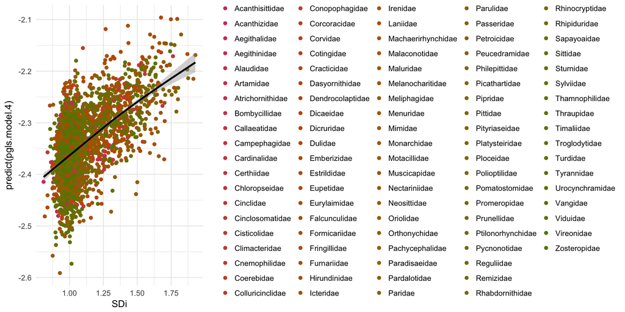

```r
predict.frame <- cbind(predict(pgls.model.4),restricted.data)
predict.frame %>% ggplot(aes(y = `predict(pgls.model.4)`, x = SDi)) +
  geom_point(aes(color = BLFamilyLatin))+
  scale_color_hue(h = c(0,100), l = 50) +
  geom_smooth(color = 'black')+
  theme_minimal()
```

### The sexual dimorphism dataset has an overdispersed distribution

It looks like some of the higher SDi’s have slightly higher speciation rates. Perhaps we can look at those obviously dimorphic groups as category of its own.

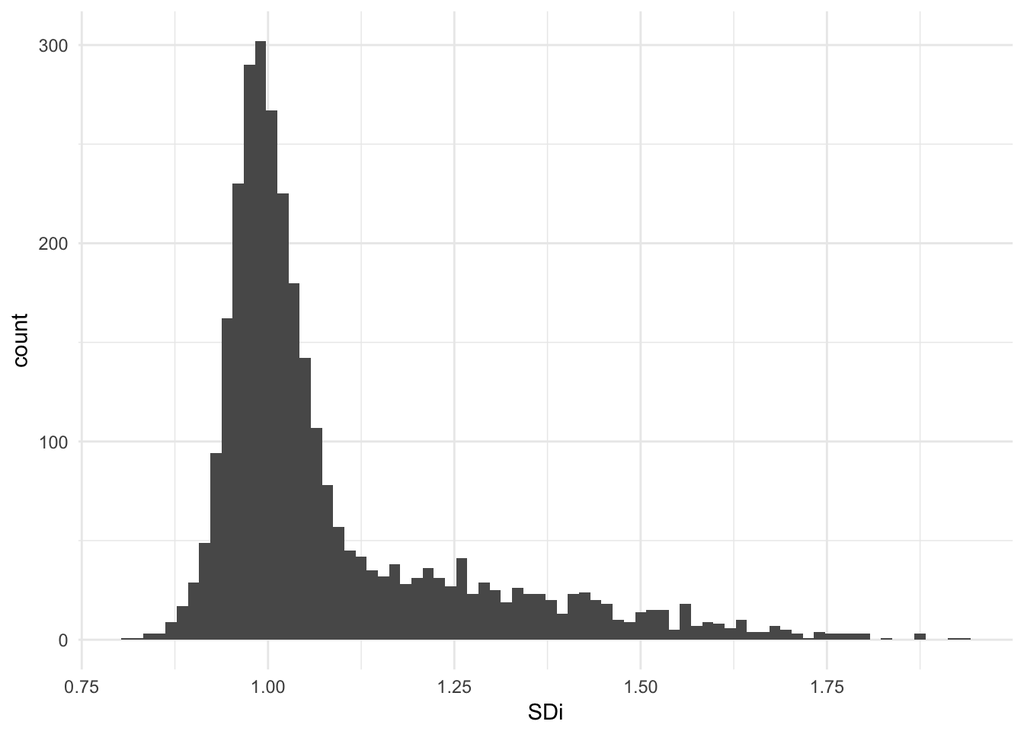

```r
restricted.data %>% ggplot(aes(SDi))+
  geom_histogram(binwidth = 0.015)+
  theme_minimal()
```

1. Harvey MG, Seeholzer GF, Smith BT, Rabosky DL, Cuervo AM, Brumfield RT. 2017 Positive association between population genetic differentiation and speciation rates in new world birds. *Proceedings of the National Academy of Sciences* **114**, 6328–6333. (doi:10.1073/pnas.1617397114)

2. Jetz W, Thomas GH, Joy JB, Hartmann K, Mooers AO. 2012 The global diversity of birds in space and time. *Nature* **491**, 444–448. (doi:10.1038/nature11631)

3. Dale J, Dey CJ, Delhey K, Kempenaers B, Valcu M. 2015 The effects of life history and sexual selection on male and female plumage colouration. *Nature* **527**, 367–370. (doi:10.1038/nature15509)

4. Armenta JK, Dunn PO, Whittingham LA. 2008 Quantifying avian sexual dichromatism: A comparison of methods. *Journal of Experimental Biology* **211**, 2423.

5. Del Hoyo J, Elliott A, Christie D. In press. *Handbook of the birds of the world*. Lynx Edicions 2003-2011.

6. Quintero I, Jetz W. 2018 Global elevational diversity and diversification of birds. *Nature* **555**, 246.

7. Harvey Michael G, Rabosky Daniel L, Cooper N. 2017 Continuous traits and speciation rates: Alternatives to state‐dependent diversification models. *Methods in Ecology and Evolution* **9**, 984–993. (doi:10.1111/2041-210X.12949)